# Airbnb data for New York City 2019

Group Dol_R

8/20/2020

## Introduction

Airbnb is an online marketplace for accommodations and it has more than 150 million users worldwide. In this report, the listing activity and metrics in New York City for 2019 will be analyzed according to **New York City Airbnb Open Data** data from [*Kaggle*](https://www.kaggle.com/dgomonov/new-york-city-airbnb-open-data).

## Loading Libraries and Data

```r
library(readr)
library(tidyverse)
library(lubridate)
library(tinytex)

data <- read.csv("https://raw.githubusercontent.com/pjournal/boun01g-dol-r/gh-pages/NYC_assignment/AB_NYC_2019.csv", header = TRUE, check.names=TRUE)
```

## Overview and Manipulation of Data

### Variables

First of all we start with checking the structure of the variables by glimpse.

```r
data %>% glimpse()
```

```
## Rows: 48,895
## Columns: 16
## $ id                             <int> 2539, 2595, 3647, 3831, 5022, 5099, 51…
## $ name                           <chr> "Clean & quiet apt home by the park", …
## $ host_id                        <int> 2787, 2845, 4632, 4869, 7192, 7322, 73…
## $ host_name                      <chr> "John", "Jennifer", "Elisabeth", "Lisa…
## $ neighbourhood_group            <chr> "Brooklyn", "Manhattan", "Manhattan", …
## $ neighbourhood                  <chr> "Kensington", "Midtown", "Harlem", "Cl…
## $ latitude                       <dbl> 40.64749, 40.75362, 40.80902, 40.68514…
## $ longitude                      <dbl> -73.97237, -73.98377, -73.94190, -73.9…
## $ room_type                      <chr> "Private room", "Entire home/apt", "Pr…
## $ price                          <int> 149, 225, 150, 89, 80, 200, 60, 79, 79…
## $ minimum_nights                 <int> 1, 1, 3, 1, 10, 3, 45, 2, 2, 1, 5, 2, …
## $ number_of_reviews              <int> 9, 45, 0, 270, 9, 74, 49, 430, 118, 16…
## $ last_review                    <chr> "2018-10-19", "2019-05-21", "", "2019-…
## $ reviews_per_month              <dbl> 0.21, 0.38, NA, 4.64, 0.10, 0.59, 0.40…
## $ calculated_host_listings_count <int> 6, 2, 1, 1, 1, 1, 1, 1, 1, 4, 1, 1, 3,…
## $ availability_365               <int> 365, 355, 365, 194, 0, 129, 0, 220, 0,…
```

Here;

- **id** : Listing ID
- **name** : Name of the Listing
- **host_id** : Host ID
- **host_name** : Host Name
- **neighbourhood_group** : Location
- **neighbourhood** : Area
- **latitude** : Latitude Coordinates
- **longitude** : Longitude Coordinates
- **room_type** : Listing Space Type
- **price** : price (in US dollars)
- **minimum_nights** : Minimum Nights
- **number_of_reviews** : Total Number of Reviews
- **last_review** : Date of the Last Review
- **reviews_per_month** :
- **calculated_host_listings_count** :
- **availability_365** :

Numerical Variables: id, host_id, latitude, longitude, price, minimum_nights, number_of_reviews, last_review, reviews_per_month, calculated_host_listings_count, availability_365.All the numerical values can be considered as discrete.  
Categorical Variables: name, host_name, neighbourhood_group, neighbourhood, room_type

Since host_id identifies the host, there is no need for host_name and the respective column can be removed.

The types of the variables seems appropiate except last_review. We change its type to date.

```r
data$last_review <- ymd(data$last_review)
data <- data %>% select(-host_name)
```

### NA values

There may be NA values missing in the data and these NA values may affect our analysis. So we check the variables having NA.

```r
data %>% select(everything()) %>% summarise_all(funs(sum(is.na(.))))
```

```
##   id name host_id neighbourhood_group neighbourhood latitude longitude
## 1  0    0       0                   0             0        0         0
##   room_type price minimum_nights number_of_reviews last_review
## 1         0     0              0                 0       10052
##   reviews_per_month calculated_host_listings_count availability_365
## 1             10052                              0                0
```

We realized that there are 10052 NA values in reviews_per_month and last_review columns. We assume that these are the places with no reviews and check:

```r
data %>% filter(number_of_reviews==0)%>%count()
```

```
##       n
## 1 10052
```

We see that there are no data with reviews_per_month = 0 so we convert the na values in reviews_per_month column to 0.

```r
data <- data %>% mutate(reviews_per_month=ifelse(is.na(reviews_per_month), 0, reviews_per_month))
```

## Analysis

Average price per night is 152.72.

### Summary of Dataset

There are 48895 data points in total.

```r
data %>% summary()
```

```
##        id               name              host_id          neighbourhood_group
##  Min.   :    2539   Length:48895       Min.   :     2438   Length:48895
##  1st Qu.: 9471945   Class :character   1st Qu.:  7822033   Class :character
##  Median :19677284   Mode  :character   Median : 30793816   Mode  :character
##  Mean   :19017143                      Mean   : 67620011
##  3rd Qu.:29152178                      3rd Qu.:107434423
##  Max.   :36487245                      Max.   :274321313
##
##  neighbourhood         latitude       longitude       room_type
##  Length:48895       Min.   :40.50   Min.   :-74.24   Length:48895
##  Class :character   1st Qu.:40.69   1st Qu.:-73.98   Class :character
##  Mode  :character   Median :40.72   Median :-73.96   Mode  :character
##                     Mean   :40.73   Mean   :-73.95
##                     3rd Qu.:40.76   3rd Qu.:-73.94
##                     Max.   :40.91   Max.   :-73.71
##
##      price         minimum_nights    number_of_reviews  last_review
##  Min.   :    0.0   Min.   :   1.00   Min.   :  0.00    Min.   :2011-03-28
##  1st Qu.:   69.0   1st Qu.:   1.00   1st Qu.:  1.00    1st Qu.:2018-07-08
##  Median :  106.0   Median :   3.00   Median :  5.00    Median :2019-05-19
##  Mean   :  152.7   Mean   :   7.03   Mean   : 23.27    Mean   :2018-10-04
##  3rd Qu.:  175.0   3rd Qu.:   5.00   3rd Qu.: 24.00    3rd Qu.:2019-06-23
##  Max.   :10000.0   Max.   :1250.00   Max.   :629.00    Max.   :2019-07-08
##                                                        NA's   :10052
##  reviews_per_month calculated_host_listings_count availability_365
##  Min.   : 0.000    Min.   :  1.000                Min.   :  0.0
##  1st Qu.: 0.040    1st Qu.:  1.000                1st Qu.:  0.0
##  Median : 0.370    Median :  1.000                Median : 45.0
##  Mean   : 1.091    Mean   :  7.144                Mean   :112.8
##  3rd Qu.: 1.580    3rd Qu.:  2.000                3rd Qu.:227.0
##  Max.   :58.500    Max.   :327.000                Max.   :365.0
##
```

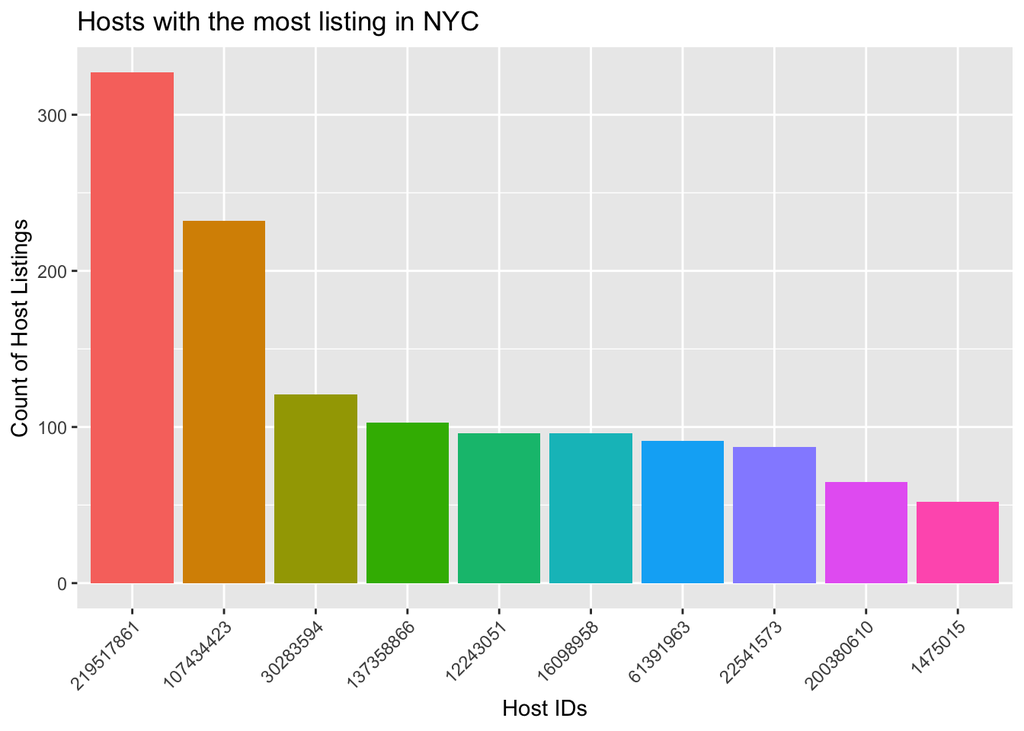

```r
top_hosts <- sort(table(data$host_id), decreasing = T)

top_hosts <- head(top_hosts, 10)
top_hosts <- data.frame(top_hosts)

bar_p <- ggplot(top_hosts, aes(x=Var1, y = Freq, fill = Var1)) + geom_bar(stat = "identity") + labs(x="Host IDs", y="Count of Host Listings", color="Host IDs", title = "Hosts with the most listing in NYC") + theme(axis.text.x = element_text(angle=45,hjust=1,vjust=1), legend.position = "none")
bar_p
```

### Neigbourhoods

Now we check the number of the neighborhood groups and dispersion among listings.

```r
data %>% select(neighbourhood_group)  %>% unique() %>% count()
```

```
##   n
## 1 5
```

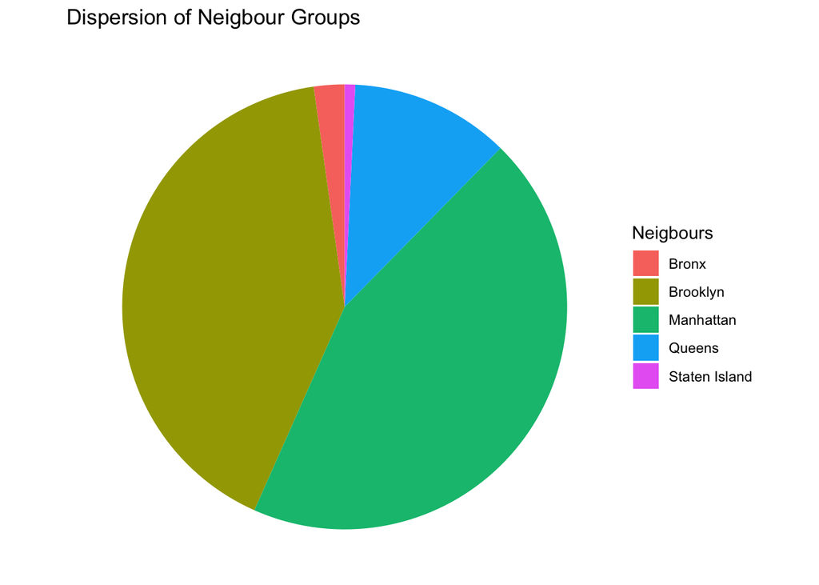

```r
df_neigbour <- data.frame(data$neighbourhood_group)
df_neigbour <- unlist(df_neigbour)
df_neigbour <- data.frame(df_neigbour)
pie_chart <- ggplot(df_neigbour) + geom_bar(mapping = aes(x = "", fill=df_neigbour ), width = 1) + coord_polar("y") +
  theme_void() # remove background, grid, numeric labels
pie_chart <- pie_chart + labs(x="", fill="Neigbours", title = "Dispersion of Neigbour Groups")
pie_chart
```

There are 5 groups (boroughs of NYC)

And now we check the number of neighborhoods in each group and top 10 frequent neigbourhoods over all listings.

```r
neighbor_count <- data %>% select(neighbourhood_group, neighbourhood)  %>% group_by(neighbourhood_group) %>% unique() %>% count()

neighbor_count
```

```
## # A tibble: 5 x 2
## # Groups:   neighbourhood_group [5]
##   neighbourhood_group     n
##   <chr>               <int>
## 1 Bronx                  48
## 2 Brooklyn               47
## 3 Manhattan              32
## 4 Queens                 51
## 5 Staten Island          43
```

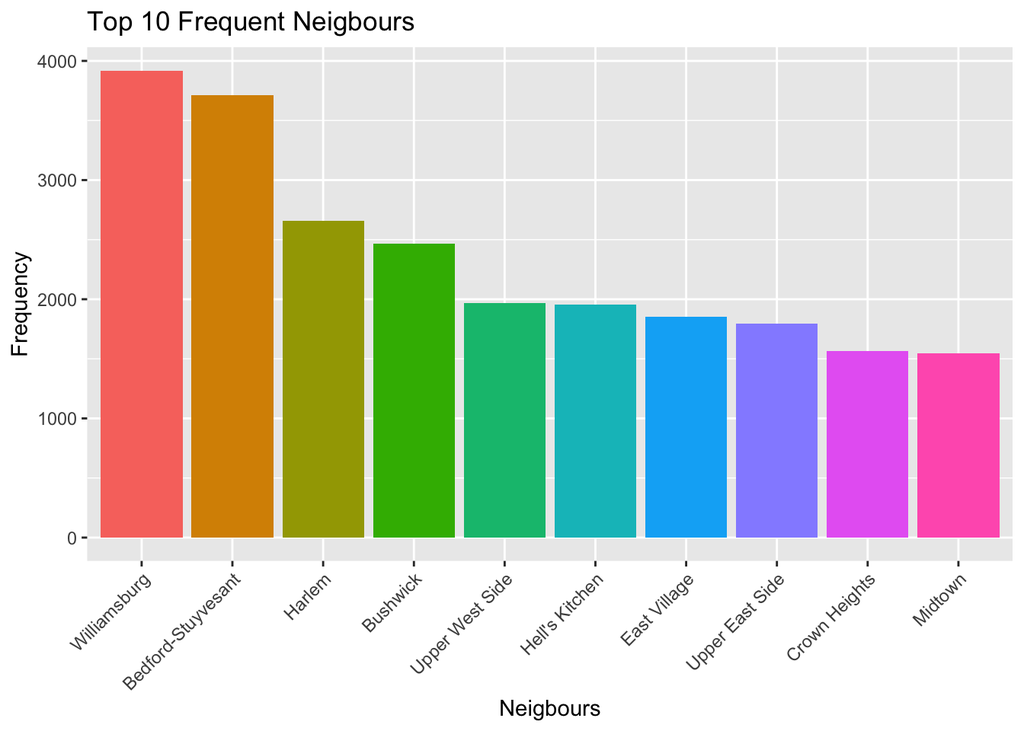

```r
top_neig <- sort(table(data$neighbourhood), decreasing = T)

top_neig <- head(top_neig, 10)
top_neig <- data.frame(top_neig)


bar_p2 <- ggplot(top_neig, aes(x=Var1, y = Freq, fill = Var1)) + geom_bar(stat = "identity") + labs(x="Neigbours", y="Frequency",color= "Neigbours", title = "Top 10 Frequent Neigbours") + theme(axis.text.x = element_text(angle=45,hjust=1,vjust=1), legend.position = "none")
bar_p2
```

We can see that there are 221 neighbourhoods in NYC.

Lets see the average price in every borough and their distributions with box-plot.

```r
data %>% group_by(neighbourhood_group) %>% transmute(mean_price = mean(price)) %>% unique()
```

```
## # A tibble: 5 x 2
## # Groups:   neighbourhood_group [5]
##   neighbourhood_group mean_price
##   <chr>                    <dbl>
## 1 Brooklyn                 124.
## 2 Manhattan                197.
## 3 Queens                    99.5
## 4 Staten Island            115.
## 5 Bronx                     87.5
```

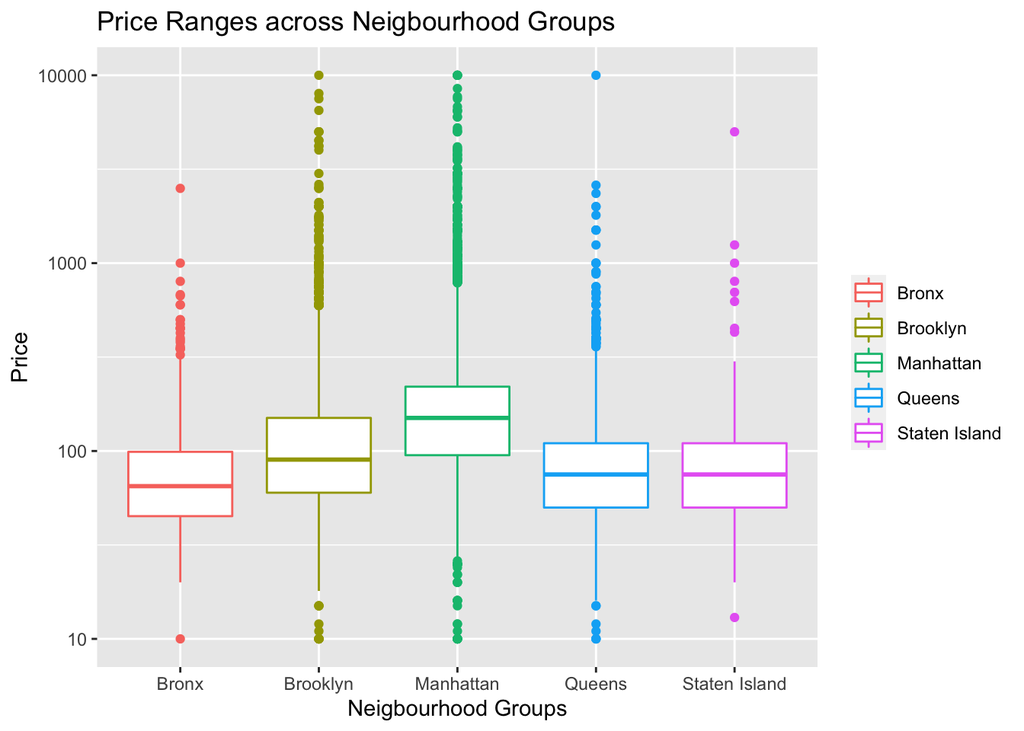

```r
box_df <- data %>% select(id, neighbourhood_group, price)

box_plot1 <- ggplot(box_df, aes(x=neighbourhood_group, y=price, color=neighbourhood_group)) + geom_boxplot() + scale_y_log10() +labs(x="Neigbourhood Groups", y="Price", title = "Price Ranges across Neigbourhood Groups") + theme(legend.title= element_blank())

box_plot1
```

There seems a huge gap between neighbourhoods. There could be several reasons for this. So we check the effect of the room types.

### Room Types

There are 3 different types of rooms which are Private room, Entire home/apt, Shared room . Mean prices per room type are :

```r
data %>% select(price, room_type) %>% group_by(room_type)%>% summarise(mean(price))
```

```
## # A tibble: 3 x 2
##   room_type       `mean(price)`
##   <chr>                   <dbl>
## 1 Entire home/apt         212.
## 2 Private room             89.8
## 3 Shared room              70.1
```

There seems a huge gap between entire home / apartment type and the others. Also it’s useful to see the ratio of the room types over the region.

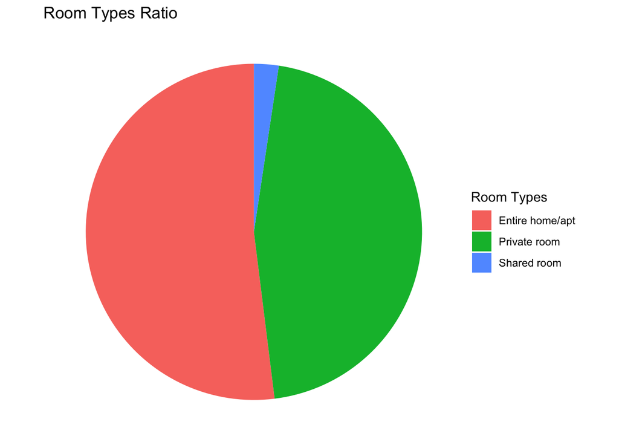

```r
df_rt <- data.frame(data$room_type)
df_rt <- unlist(df_rt)
df_rt <- data.frame(df_rt)
pie_chart2 <- ggplot(df_rt) + geom_bar(mapping = aes(x = "", fill=df_rt ), width = 1) + coord_polar("y") +
  theme_void() # remove background, grid, numeric labels
pie_chart2 <- pie_chart2 + labs(x="", fill="Room Types", title = "Room Types Ratio")
pie_chart2
```

### Hosts with the Most Listings in NYC

Speaking of hosts, it can give clues about availability througout the year. They can be listed as descending order based on listings.

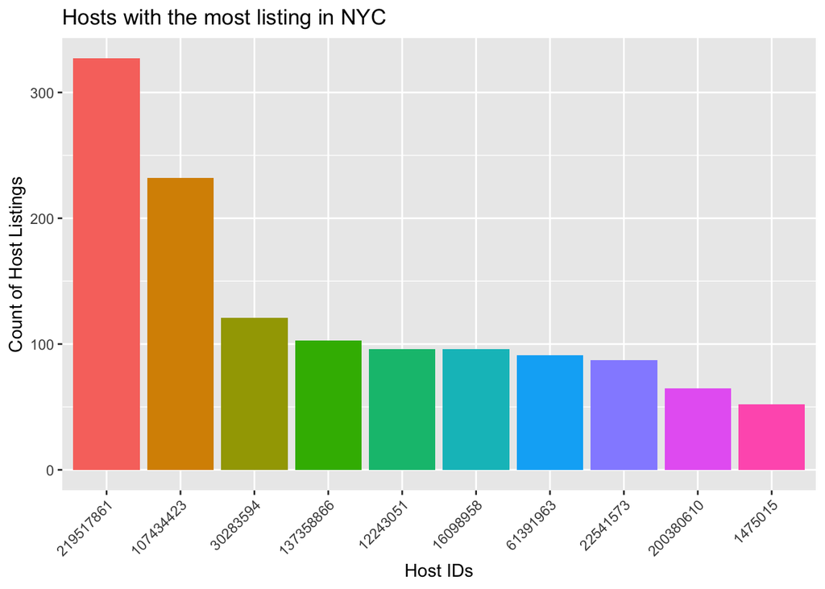

```r
top_hosts <- sort(table(data$host_id), decreasing = T)

top_hosts <- head(top_hosts, 10)
top_hosts <- data.frame(top_hosts)


bar_p <- ggplot(top_hosts, aes(x=Var1, y = Freq, fill = Var1)) + geom_bar(stat = "identity") + labs(x="Host IDs", y="Count of Host Listings", color="Host IDs", title = "Hosts with the most listing in NYC") + theme(axis.text.x = element_text(angle=45,hjust=1,vjust=1),legend.position = "none")
bar_p
```

### Number of Reviews

We check the effect of the number of reviews.

```r
review_0_15_mean <- mean((data %>%  filter (number_of_reviews <=15) %>% select(price))$price) %>% round()
review_15_25_mean <- mean((data %>%  filter (number_of_reviews >15 & number_of_reviews <=25) %>% select(price))$price)  %>% round()
review_25_50_mean <- mean((data %>%  filter (number_of_reviews >25 & number_of_reviews <=50) %>% select(price))$price)  %>% round()
review_50_100_mean <- mean((data %>%  filter (number_of_reviews >50 & number_of_reviews <=100) %>% select(price))$price) %>% round()
review_100_200_mean <- mean((data %>%  filter (number_of_reviews >100 & number_of_reviews <=200) %>% select(price))$price)  %>% round()
review_200plus_mean <- mean((data %>%  filter (number_of_reviews >200) %>% select(price))$price)  %>% round()
```

Average price of places with number of reviews:

0 to 15 : 161 USD

15 to 25 : 141 USD *Around the average number of reviews*

25 to 50 : 137 USD

50 to 100 : 130 USD

100 to 200 : 130 USD

200 and above : 114 USD

We can understand that number of reviews has no positive effect on price since it is possible that customers prefer to choose places with low price.

Furthermore we check the house types in boroughs. It may explain the price gap. From the data we see, we can assume that there are more entire house / apartment offers in manhattan than the others.

```r
data %>% select(neighbourhood_group,room_type) %>% group_by(neighbourhood_group,room_type) %>% count() %>% group_by(neighbourhood_group) %>% mutate(total_in_borough = sum(n)) %>% mutate (percentage = paste0(as.character(round(n / total_in_borough*100)),"%")) %>% select(-total_in_borough)
```

```
## # A tibble: 15 x 4
## # Groups:   neighbourhood_group [5]
##    neighbourhood_group room_type           n percentage
##    <chr>               <chr>           <int> <chr>
##  1 Bronx               Entire home/apt   379 35%
##  2 Bronx               Private room      652 60%
##  3 Bronx               Shared room        60 5%
##  4 Brooklyn            Entire home/apt  9559 48%
##  5 Brooklyn            Private room    10132 50%
##  6 Brooklyn            Shared room       413 2%
##  7 Manhattan           Entire home/apt 13199 61%
##  8 Manhattan           Private room     7982 37%
##  9 Manhattan           Shared room       480 2%
## 10 Queens              Entire home/apt  2096 37%
## 11 Queens              Private room     3372 60%
## 12 Queens              Shared room       198 3%
## 13 Staten Island       Entire home/apt   176 47%
## 14 Staten Island       Private room      188 50%
## 15 Staten Island       Shared room         9 2%
```

### Landmarks

AirBnb is used by tourists and travellers mostly. A tourist usually prefers to stay close to the places where they plan to visit which are commonly the landmarks of the city. We select several landmarks of NYC from [here](https://www.planetware.com/tourist-attractions-/new-york-city-us-ny-nyc.htm). This list shows the most popular tourist attractions. And we find the coordinates from [here](https://www.latlong.net/), a coordinate search engine.

```r
Landmarks <- read_csv2("https://raw.githubusercontent.com/pjournal/boun01g-dol-r/gh-pages/NYC_assignment/landmarks_NYC.csv")

Landmarks <- as.tibble(Landmarks)

Landmarks%>%glimpse()
```

```
## Rows: 9
## Columns: 3
## $ `Tourist Attraction` <chr> "Rockefeller Center", "Metropolitan Museum of Ar…
## $ Latitude             <dbl> 40.75874, 40.77896, 40.74882, 40.71008, 40.75890…
## $ Longitude            <dbl> -73.97867, -73.96231, -73.98543, -74.01241, -73.…
```

We load our landmarks. These landmarks we choose are:

-Rockefeller Center

-Metropolitan Museum of Art

-Empire State Building

-9/11 Memorial and Museum

-Times Square

-Grand Central Terminal

-One World Observatory

-New York Public Library

-St. Patrick’s Cathedral

And now we will calculate the average distance of every single house to these landmarks. We use a package called geosphere with which we can calculate the distance between two coordinates.

```r
library(geosphere)
data <- data%>% rowwise() %>% mutate(rock_dist = distm (cbind(Landmarks$Longitude[1], Landmarks$Latitude[1]), cbind(longitude,latitude), fun = distHaversine))

data <- data%>% rowwise() %>% mutate(Met_dist = distm (cbind(Landmarks$Longitude[2], Landmarks$Latitude[2]), cbind(longitude,latitude), fun = distHaversine))

data <- data%>% rowwise() %>% mutate(Emp_State_dist = distm (cbind(Landmarks$Longitude[3], Landmarks$Latitude[3]), cbind(longitude,latitude), fun = distHaversine))

data <- data%>% rowwise() %>% mutate(NineElevenMemo_dist = distm (cbind(Landmarks$Longitude[4], Landmarks$Latitude[4]), cbind(longitude,latitude), fun = distHaversine))

data <- data%>% rowwise() %>% mutate(TimesSq_dist = distm (cbind(Landmarks$Longitude[5], Landmarks$Latitude[5]), cbind(longitude,latitude), fun = distHaversine))

data <- data%>% rowwise() %>% mutate(Terminal_dist = distm (cbind(Landmarks$Longitude[6], Landmarks$Latitude[6]), cbind(longitude,latitude), fun = distHaversine))

data <- data%>% rowwise() %>% mutate(OneWorld_dist = distm (cbind(Landmarks$Longitude[7], Landmarks$Latitude[7]), cbind(longitude,latitude), fun = distHaversine))

data <- data%>% rowwise() %>% mutate(Library_dist = distm (cbind(Landmarks$Longitude[8], Landmarks$Latitude[8]), cbind(longitude,latitude), fun = distHaversine))

data <- data%>% rowwise() %>% mutate(StPatrick_dist = distm (cbind(Landmarks$Longitude[9], Landmarks$Latitude[9]), cbind(longitude,latitude), fun = distHaversine))

data <- data %>% mutate(Mean_Distance = mean(rock_dist,Met_dist,Emp_State_dist,NineElevenMemo_dist,TimesSq_dist, Terminal_dist,OneWorld_dist,Library_dist,StPatrick_dist))
```

Now we will check the possible effect of location to the prices. We will start with plotting. (We filter prices < 750 since there are outliers above and the graph do not mean anything.)

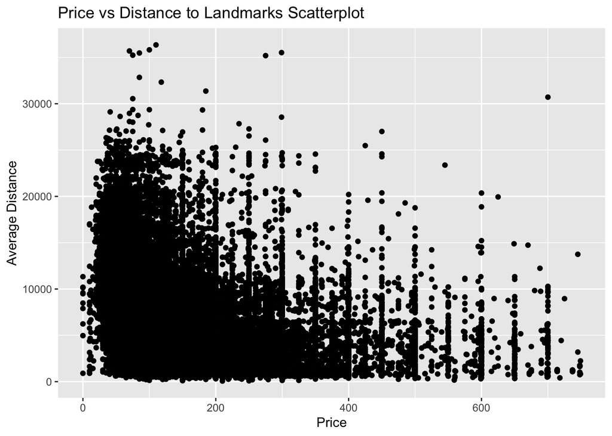

```r
data %>% filter(price<750) %>% ggplot(.,aes(x=price,y=Mean_Distance)) + geom_point(color = "black") + labs(x="Price",y="Average Distance") + ggtitle("Price vs Distance to Landmarks Scatterplot")
```

We can see that high proportion of the places with higher price has shorter distance. But there are around 50K observations and this makes us harder to understand the graphics. Therefore we calculate the mean distance and mean prices of neighborhood.

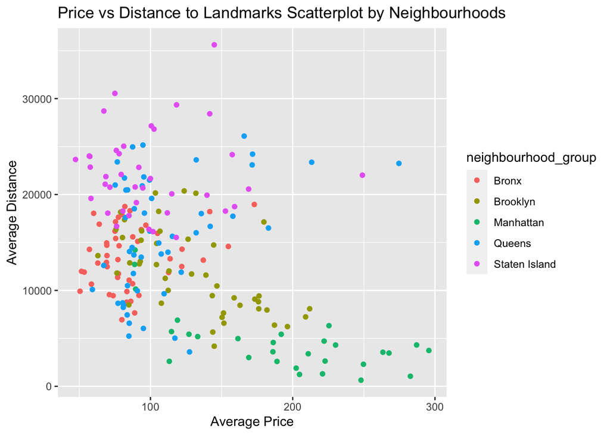

```r
Mean_Price_Dist_data <- data %>% select(neighbourhood_group,neighbourhood,Mean_Distance,price) %>% group_by(neighbourhood_group,neighbourhood) %>% mutate(mean_price_neig = mean(price)) %>% mutate(mean_dist_neig = mean(Mean_Distance)) %>% select(-Mean_Distance, -price) %>% group_by(neighbourhood_group) %>% unique() %>% arrange(neighbourhood_group)



Mean_Price_Dist_data %>% filter (mean_price_neig <300) %>% ggplot(.,aes(mean_price_neig,mean_dist_neig,color=neighbourhood_group)) +geom_point() + labs(x="Average Price",y="Average Distance") + ggtitle("Price vs Distance to Landmarks Scatterplot by Neighbourhoods")
```

## References

To see Group Dol_R’s Progress Journal, visit [Progress Journal website](https://pjournal.github.io/boun01g-dol-r/).